# FE8828 Assignment for Exploratory Data Analysis

Toh Zhao Zhi <sub><Email: tohz0016pg@e.ntu.edu.sg></sub>

Nov 19, 2017

# Finding #1

This data contains 4521 number of data points.

# Finding #2 Marital Status Demographics of Sample

Proportion of data sample for each marital status:

| marital | n |
| --- | --- |
| divorced | 528 |
| married | 2797 |
| single | 1196 |

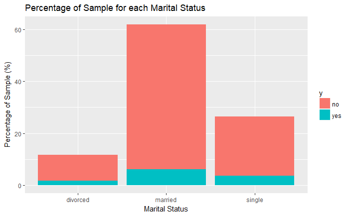

528 of the people in the sample are divorced, 2797 are married and 1196 are single of which majority of the people in each category have not subscribed to the term deposit.

# Finding #3 Age Demographics of Sample

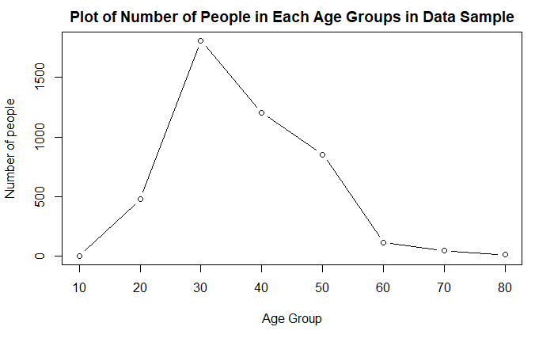

In the above analysis, people in the sample were categorized into age groups of 10+, 20+, 30+,…, 80+. It can be seen that the majority of the data sample is made up of people in their 30s and the second largest group would be the people in their 40s.

# Finding #4 Mean Balance across Age Groups

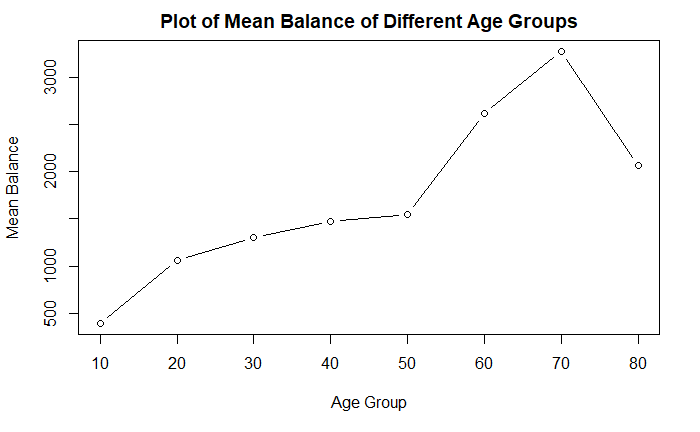

| age_group | count | balance_mean |
| --- | --- | --- |
| 10 | 4 | 393.500 |
| 20 | 478 | 1063.657 |
| 30 | 1808 | 1298.147 |
| 40 | 1203 | 1474.692 |
| 50 | 854 | 1547.420 |
| 60 | 113 | 2619.779 |
| 70 | 47 | 3280.872 |
| 80 | 14 | 2071.143 |

The above plot shows the mean balance across different age groups and it can be observed that on average, people above 60 years old have higher balances as compared to people below 60 years old. People in their 70s have highest mean balance, while people aged 10+ have the lowest mean balance.

# Finding #5 Likelihood of default in each job category

| job | default_count | total | likelihood.default |
| --- | --- | --- | --- |
| admin. | 6 | 141 | 4.255319 |
| blue-collar | 14 | 198 | 7.070707 |
| entrepreneur | 7 | 62 | 11.290323 |
| housemaid | 2 | 65 | 3.076923 |
| management | 14 | 407 | 3.439803 |
| retired | 3 | 161 | 1.863354 |
| self-employed | 4 | 80 | 5.000000 |
| services | 7 | 99 | 7.070707 |
| student | 1 | 63 | 1.587302 |
| technician | 15 | 298 | 5.033557 |

[output cut: 2 more lines]

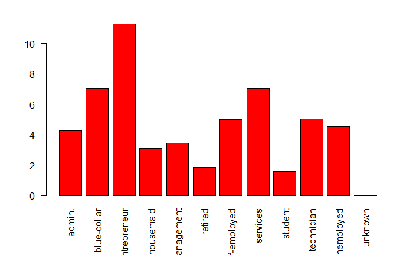

The above bar chart shows the default likelihood across different job categories. It can be seen that entrepreneurs have the highest possibility of defaulting on their loans, while unknown, students and retired have the lowest possibility of defaulting on their loans.

# Finding #6 Education-Job Relationship

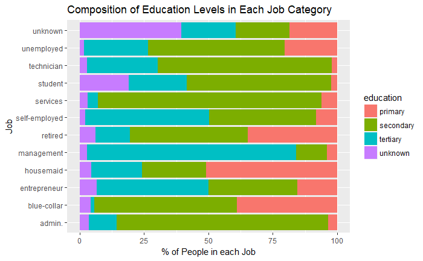

| job | education | n | Percentage in Job Category |
| --- | --- | --- | --- |
| admin. | primary | 17 | 3.556485 |
| admin. | secondary | 393 | 82.217573 |
| admin. | tertiary | 51 | 10.669456 |
| admin. | unknown | 17 | 3.556485 |
| blue-collar | primary | 369 | 39.006342 |
| blue-collar | secondary | 524 | 55.391121 |
| blue-collar | tertiary | 12 | 1.268499 |
| blue-collar | unknown | 41 | 4.334038 |
| entrepreneur | primary | 26 | 15.476190 |
| entrepreneur | secondary | 58 | 34.523810 |

[output cut: 38 more lines]

The above chart shows the composition of Education Levels in Each Job Category. It can be seen that management level jobs are mostly taken up by people with tertiary education level, while services, admin, services, technicians are mostly taken up by people with secondary education. Housemaids is mainly composed of people with primary education.

# Finding #7 Job-Age Relationship

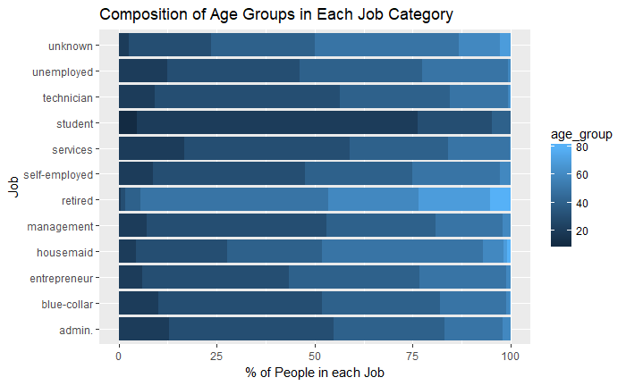

| job | age_group | n | Percentage in Job Category |
| --- | --- | --- | --- |
| admin. | 20 | 62 | 12.9707113 |
| admin. | 30 | 200 | 41.8410042 |
| admin. | 40 | 135 | 28.2426778 |
| admin. | 50 | 71 | 14.8535565 |
| admin. | 60 | 10 | 2.0920502 |
| blue-collar | 20 | 96 | 10.1479915 |
| blue-collar | 30 | 395 | 41.7547569 |
| blue-collar | 40 | 285 | 30.1268499 |
| blue-collar | 50 | 160 | 16.9133192 |
| blue-collar | 60 | 8 | 0.8456660 |

[output cut: 57 more lines]

# Finding #8 Min and Max Balance in each job category

| job | min_balance | max_balance | mean_balance |
| --- | --- | --- | --- |
| admin. | -967 | 22171 | 1226.736 |
| blue-collar | -1400 | 16353 | 1085.162 |
| entrepreneur | -2082 | 42045 | 1645.125 |
| housemaid | -759 | 26965 | 2083.804 |
| management | -1746 | 27359 | 1766.929 |
| retired | -1206 | 71188 | 2319.191 |
| self-employed | -3313 | 16430 | 1392.410 |
| services | -1202 | 26394 | 1103.957 |
| student | -230 | 11555 | 1543.821 |
| technician | -1680 | 27733 | 1330.996 |

[output cut: 2 more lines]

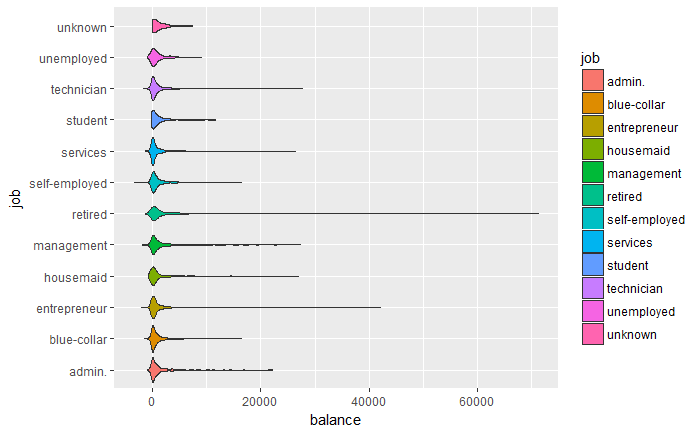

The above plot shows the distribution of balance in the different job categories. The maximum balance of the sample comes from the retired category (71188), while the minimum balance of the sample comes from the self-employed category (-3313).

# Finding #9 Age range of people with housing loan

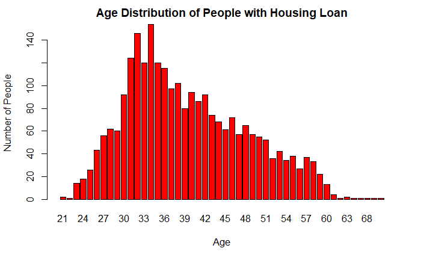

| age | housing | n |
| --- | --- | --- |
| 21 | yes | 2 |
| 22 | yes | 1 |
| 23 | yes | 14 |
| 24 | yes | 18 |
| 25 | yes | 26 |
| 26 | yes | 43 |
| 27 | yes | 56 |
| 28 | yes | 62 |
| 29 | yes | 60 |
| 30 | yes | 92 |

[output cut: 38 more lines]

The above chart shows the age distribution of people with housing loan. The age range of people with housing loan is 21 to 75. It can be seen that the bulk of people with housing loans are aged 30-42, with the age 34 having the most people with a housing loan. In general, as age increases/decreases from the 30s, the number of people having housing loans decreases.

# Finding #10 Age range of people with personal loan

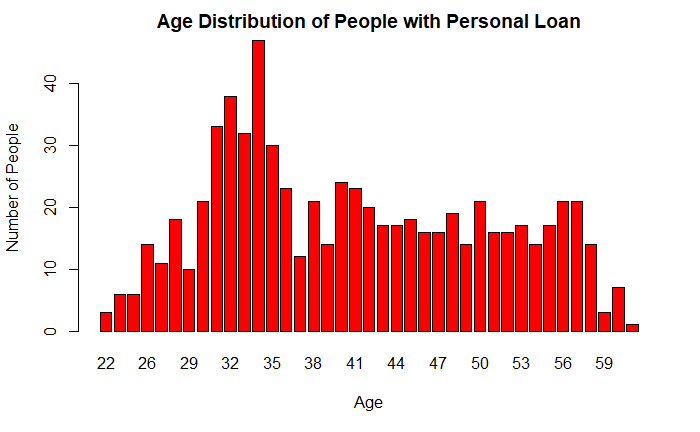

| age | loan | n |
| --- | --- | --- |
| 22 | yes | 3 |
| 24 | yes | 6 |
| 25 | yes | 6 |
| 26 | yes | 14 |
| 27 | yes | 11 |
| 28 | yes | 18 |
| 29 | yes | 10 |
| 30 | yes | 21 |
| 31 | yes | 33 |
| 32 | yes | 38 |

[output cut: 29 more lines]